# HDS5301: Regression Methods – HW 2 Answer Key

Published

February 10, 2026

1. On Slide 44 (Lec02-SLR2.html), it says that to test $H_0: \beta_0 = \beta_{0,0}$, we can use the test statistics:
   $$T = \frac{b_0 - \beta_{0,0}}{s_{b_0}} = \frac{b_0 - \beta_{0,0}}{s \sqrt{\frac{1}{n} + \frac{\bar{x}^2}{S_{xx}}}} \sim t_{n-2}$$
   Explain why $T$ has a $t$ distribution with $n-2$ degrees of freedom under $H_0$. Give as much details as you can.

**Answer:**

Under assumptions (A.1)-(A.4) of the SLR model, the least squares estimator $b_0$ follows a normal distribution:
$$b_0 \sim N\left(\beta_0, \sigma^2 \left(\frac{1}{n} + \frac{\bar{x}^2}{S_{xx}}\right)\right)$$
Standardizing $b_0$ under the null hypothesis $H_0: \beta_0 = \beta_{0,0}$ gives a standard normal variable $Z$:
$$Z = \frac{b_0 - \beta_{0,0}}{\sqrt{\sigma^2 \left(\frac{1}{n} + \frac{\bar{x}^2}{S_{xx}}\right)}} \sim N(0, 1)$$
The error variance $\sigma^2$ is estimated by $s^2 = SSE/(n-2)$. We know that:
$$V = \frac{(n-2)s^2}{\sigma^2} = \frac{SSE}{\sigma^2} \sim \chi^2_{n-2}$$
Furthermore, $b_0$ and $s^2$ are statistically independent.

The definition of a random variable with a $t$-distribution is the ratio of a standard normal variable to the square root of an independent $\chi^2$ variable divided by its degrees of freedom. Thus:
$$T = \frac{Z}{\sqrt{V/(n-2)}} = \frac{\frac{b_0 - \beta_{0,0}}{\sigma \sqrt{\frac{1}{n} + \frac{\bar{x}^2}{S_{xx}}}}}{\sqrt{\frac{(n-2)s^2}{\sigma^2} \cdot \frac{1}{n-2}}} = \frac{b_0 - \beta_{0,0}}{s \sqrt{\frac{1}{n} + \frac{\bar{x}^2}{S_{xx}}}} = \frac{b_0 - \beta_{0,0}}{s_{b_0}}$$
Therefore, $T \sim t_{n-2}$.

2. Under the SLR model, $y_i=\beta_0+\beta_1 x_i+\epsilon_i$, the estimated regression coefficients are
   $$\begin{aligned}
   b_1 &= \frac{S_{xy}}{S_{xx}} = \frac{\sum_{i=1}^n (x_i - \bar{x})(y_i - \bar{y})}{\sum_{i=1}^n (x_i - \bar{x})^2} \\
   b_0 &= \bar{y} - b_1 \bar{x}
   \end{aligned}$$
   1. Suppose we center the predictor variable by defining a new variable $x_i' = x_i- \bar{x}$. Now we fit the SLR model $y_i=\beta_0+\beta_1 x_i'+\epsilon_i$, how would the estimated regression coefficients change?

   **Answer:**

   The new slope $b_1'$ is:
   $$b_1' = \frac{\sum (x_i' - \bar{x}')(y_i - \bar{y})}{\sum (x_i' - \bar{x}')^2}$$
   Since $\bar{x}' = \frac{1}{n}\sum(x_i - \bar{x}) = 0$, $x_i' - \bar{x}' = x_i - \bar{x}$. So $b_1' = b_1$. The slope remains the same.

   The new intercept $b_0'$ is:
   $$b_0' = \bar{y} - b_1' \bar{x}' = \bar{y} - b_1 (0) = \bar{y}$$
   2. Suppose we also center the response variable by defining a new variable $y_i' = y_i - \bar{y}$. Now we fit the SLR model $y_i'=\beta_0+\beta_1 x_i'+\epsilon_i$, how would the estimated regression coefficients change?

   **Answer:**

   New variables: $x_i' = x_i - \bar{x}$, $y_i' = y_i - \bar{y}$. Note $\bar{x}' = 0, \bar{y}' = 0$.
   $$b_1'' = \frac{\sum (x_i' - \bar{x}')(y_i' - \bar{y}')}{\sum (x_i' - \bar{x}')^2} = \frac{\sum (x_i - \bar{x})(y_i - \bar{y})}{\sum (x_i - \bar{x})^2} = b_1$$
   The slope remains the same.
   $$b_0'' = \bar{y}' - b_1'' \bar{x}' = 0 - b_1(0) = 0$$
   3. Suppose we multiply the predictor variable by a constant $c$, i.e., $x_i^*=x_i c$; and the response variable by a constant $d$, i.e., $y_i^* = y_i d$. Now fit the SLR model $y_i^*=\beta_0+\beta_1 x_i^*+\epsilon_i$. How would the estimated regression coefficients change?

   **Answer:**

   $\bar{x}^* = c\bar{x}$, $\bar{y}^* = d\bar{y}$.

   $S_{x^*x^*} = \sum (cx_i - c\bar{x})^2 = c^2 S_{xx}$.

   $S_{x^*y^*} = \sum (cx_i - c\bar{x})(dy_i - d\bar{y}) = cd S_{xy}$.
   $$b_1^* = \frac{S_{x^*y^*}}{S_{x^*x^*}} = \frac{cd S_{xy}}{c^2 S_{xx}} = \frac{d}{c} b_1$$
   The slope is scaled by $d/c$.
   $$b_0^* = \bar{y}^* - b_1^* \bar{x}^* = d\bar{y} - \left(\frac{d}{c} b_1\right) c\bar{x} = d(\bar{y} - b_1 \bar{x}) = d b_0$$
   The intercept is scaled by $d$.
   4. Suppose we standardize the predictor variable and response variable, i.e., $x_i^{\dag} = (x_i - \bar{x})/s_x$ and $y_i^{\dag} = (y_i - \bar{y})/s_y$, where $s_x$ and $s_y$ are the sample standard deviations of $x$ and $y$. Now fit the SLR model $y_i^{\dag}=\beta_0+\beta_1 x_i^{\dag}+\epsilon_i$. How would the estimated regression coefficients change?

   **Answer:**

   This is a special case of (c) applied to centered data. Let $x_i' = x_i - \bar{x}$, $y_i' = y_i - \bar{y}$. Then $x_i^\dag = x_i'/s_x$, $y_i^\dag = y_i'/s_y$. Essentially $c = 1/s_x, d = 1/s_y$. Using results from (b) and (c): From (b), intercept is 0 for centered data, so scaling them maintains intercept 0.
   $$b_0^\dag = 0$$
   From (c), the slope is scaled by $d/c = (1/s_y)/(1/s_x) = s_x/s_y$.
   $$b_1^\dag = \frac{s_x}{s_y} b_1 = \frac{s_x}{s_y} \left( r \frac{s_y}{s_x} \right) = r$$
   The slope becomes the Pearson correlation coefficient $r$.
3. In the R dataset `cars`, there are two variables: `speed` (in mph) and `dist` (stopping distance in ft). You can use the following code to load the dataset. Program in R to answer the following questions. Don’t use the R function `lm()` until you finish all the calculations using your own code. Provide the R code.

```r
data(cars)
y=cars$dist # response variable
x=cars$speed # predictor variable
```

**(a)** Obtain the following terms: $S_{xx}$ and $S_{xy}$.

**Answer:**

```r
n <- length(x)
mu_x <- mean(x)
mu_y <- mean(y)
Sxx <- sum((x - mu_x)^2)
Sxy <- sum((x - mu_x) * (y - mu_y))
cat("Sxx =", Sxx, "\n")
```

```
Sxx = 1370
```

```r
cat("Sxy =", Sxy, "\n")
```

```
Sxy = 5387.4
```

**(b)** Obtain $SSE$, $SSR$, and $SST$. Verify that $SST = SSR + SSE$ holds.

**Answer:**

```r
b1 <- Sxy / Sxx
b0 <- mu_y - b1 * mu_x
y_hat <- b0 + b1 * x

SST <- sum((y - mu_y)^2)
SSE <- sum((y - y_hat)^2)
SSR <- sum((y_hat - mu_y)^2)

cat("SSE =", SSE, "\n")
```

```
SSE = 11353.52
```

```r
cat("SSR =", SSR, "\n")
```

```
SSR = 21185.46
```

```r
cat("SST =", SST, "\n")
```

```
SST = 32538.98
```

```r
cat("SSR + SSE =", SSR + SSE, "\n")
```

```
SSR + SSE = 32538.98
```

```r
# Check if they are equal (within floating point tolerance)
all.equal(SST, SSR + SSE)
```

```
[1] TRUE
```

**(c)** Compute the estimated regression coefficients $b_0$ and $b_1$, as well as the estimate of error variance $s^2$. Compare your results with those obtained from the R function `lm()`.

**Answer:**

```r
s2 <- SSE / (n - 2)

cat("b0 =", b0, "\n")
```

```
b0 = -17.57909
```

```r
cat("b1 =", b1, "\n")
```

```
b1 = 3.932409
```

```r
cat("s2 =", s2, "\n")
```

```
s2 = 236.5317
```

```r
# Compare with lm()
fit <- lm(dist ~ speed, data = cars)
summary(fit)$coefficients
```

```
              Estimate Std. Error   t value     Pr(>|t|)
(Intercept) -17.579095  6.7584402 -2.601058 1.231882e-02
speed         3.932409  0.4155128  9.463990 1.489836e-12
```

```r
cat("lm s2 =", summary(fit)$sigma^2, "\n")
```

```
lm s2 = 236.5317
```

**(d)** Conduct hypothesis tests for $H_0: \beta_1 = 0$ and $H_0: \beta_0 = 0$ at significance level $\alpha = 0.05$. State your conclusions.

**Answer:**

```r
s <- sqrt(s2)
se_b1 <- s / sqrt(Sxx)
t_b1 <- b1 / se_b1
p_b1 <- 2 * pt(-abs(t_b1), df = n - 2)

se_b0 <- s * sqrt(1/n + mu_x^2 / Sxx)
t_b0 <- b0 / se_b0
p_b0 <- 2 * pt(-abs(t_b0), df = n - 2)

cat("Test for beta1: t =", t_b1, "p-value =", p_b1, "\n")
```

```
Test for beta1: t = 9.46399 p-value = 1.489836e-12
```

```r
cat("Test for beta0: t =", t_b0, "p-value =", p_b0, "\n")
```

```
Test for beta0: t = -2.601058 p-value = 0.01231882
```

Since $p < 0.05$ for both tests, we reject $H_0: \beta_1 = 0$ and $H_0: \beta_0 = 0$. There is a significant linear relationship between speed and distance, and the intercept is significantly different from 0.

**(e)** Construct a 95% confidence interval for $\beta_1$ and interpret it.

**Answer:**

```r
alpha <- 0.05
t_crit <- qt(1 - alpha/2, df = n - 2)
ci_b1 <- c(b1 - t_crit * se_b1, b1 + t_crit * se_b1)

cat("95% CI for beta1:", ci_b1, "\n")
```

```
95% CI for beta1: 3.096964 4.767853
```

We are 95% confident that the true slope $\beta_1$ (the increase in stopping distance for every 1 mph increase in speed) is between 3.097 and 4.768. Or, if we repeat the sampling process many times, approximately 95% of the confidence intervals constructed in this way will contain the true slope $\beta_1$.

**(f)** Report the coefficient of determination $R^2$ and interpret it.

**Answer:**

```r
R2 <- 1 - SSE / SST
cat("R-squared =", R2, "\n")
```

```
R-squared = 0.6510794
```

$R^2 \approx 0.65$. Approximately 65% of the variation in stopping distance is explained by the linear regression on speed.

**(g)** Compare your results in (c)-(f) with those obtained from the R function `lm()`.

**Answer:**

```r
summary(fit)
```

```
Call:
lm(formula = dist ~ speed, data = cars)

Residuals:
    Min      1Q  Median      3Q     Max
-29.069  -9.525  -2.272   9.215  43.201

Coefficients:
            Estimate Std. Error t value Pr(>|t|)
(Intercept) -17.5791     6.7584  -2.601   0.0123 *
speed         3.9324     0.4155   9.464 1.49e-12 ***
---
Signif. codes:  0 '***' 0.001 '**' 0.01 '*' 0.05 '.' 0.1 ' ' 1

Residual standard error: 15.38 on 48 degrees of freedom
Multiple R-squared:  0.6511,    Adjusted R-squared:  0.6438
F-statistic: 89.57 on 1 and 48 DF,  p-value: 1.49e-12
```

```r
confint(fit)
```

```
                 2.5 %    97.5 %
(Intercept) -31.167850 -3.990340
speed         3.096964  4.767853
```

The results from manual calculation match the `lm()` output exactly. Congratulations!

**(h)** Use the fitted model to predict the **mean** of stopping distance when the speed is 15 mph and 25 mph. Provide 95% confidence intervals for these predictions.

**Answer:**

```r
x_new <- c(15, 25)
mu_hat <- b0 + b1 * x_new

se_mu <- s * sqrt(1/n + (x_new - mu_x)^2 / Sxx)
ci_mu_lower <- mu_hat - t_crit * se_mu
ci_mu_upper <- mu_hat + t_crit * se_mu

results_mean <- data.frame(Speed = x_new, Mean_Pred = mu_hat,
                           Lower_CI = ci_mu_lower, Upper_CI = ci_mu_upper)
print(results_mean)
```

```
  Speed Mean_Pred Lower_CI Upper_CI
1    15  41.40704 37.02115 45.79292
2    25  80.73112 71.59608 89.86617
```

```r
# Verify with predict()
predict(fit, newdata = data.frame(speed = x_new), interval = "confidence")
```

```
       fit      lwr      upr
1 41.40704 37.02115 45.79292
2 80.73112 71.59608 89.86617
```

**(i)** Use the fitted model to predict the stopping distance when the speed is 15 mph and 25 mph. Provide 95% **prediction intervals** for these predictions.

**Answer:**

```r
se_pred <- s * sqrt(1 + 1/n + (x_new - mu_x)^2 / Sxx)
pi_lower <- mu_hat - t_crit * se_pred
pi_upper <- mu_hat + t_crit * se_pred

results_pred <- data.frame(Speed = x_new, Pred = mu_hat,
                           Lower_PI = pi_lower, Upper_PI = pi_upper)
print(results_pred)
```

```
  Speed     Pred Lower_PI  Upper_PI
1    15 41.40704 10.17482  72.63925
2    25 80.73112 48.48730 112.97495
```

```r
# Verify with predict()
predict(fit, newdata = data.frame(speed = x_new), interval = "prediction")
```

```
       fit      lwr       upr
1 41.40704 10.17482  72.63925
2 80.73112 48.48730 112.97495
```

**(j)** Create a scatterplot of `dist` vs `speed`, add the fitted regression line, and add the 95% confidence band for the regression line.

**Answer:**

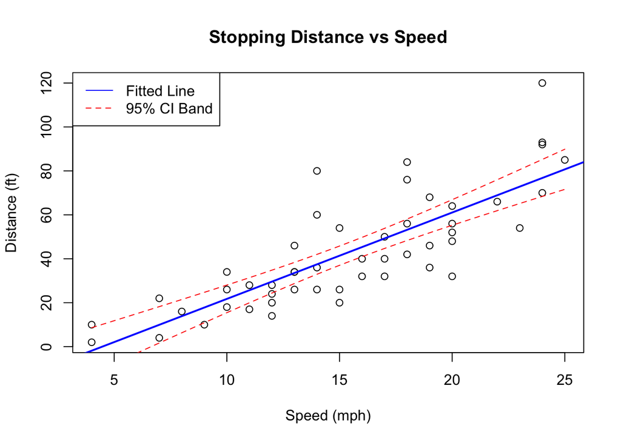

```r
plot(x, y, xlab = "Speed (mph)", ylab = "Distance (ft)",
     main = "Stopping Distance vs Speed")
abline(fit, col = "blue", lwd = 2)

# Add confidence bands
x_seq <- seq(min(x), max(x), length.out = 100)
preds <- predict(fit, newdata = data.frame(speed = x_seq), interval = "confidence")
lines(x_seq, preds[,"lwr"], col = "red", lty = 2)
lines(x_seq, preds[,"upr"], col = "red", lty = 2)
legend("topleft", legend = c("Fitted Line", "95% CI Band"),
       col = c("blue", "red"), lty = c(1, 2))
```

**(k)** Plot the residuals vs the fitted values. Comment on any patterns you observe. Do the residuals appear to satisfy the assumptions of the SLR model?

**Answer:**

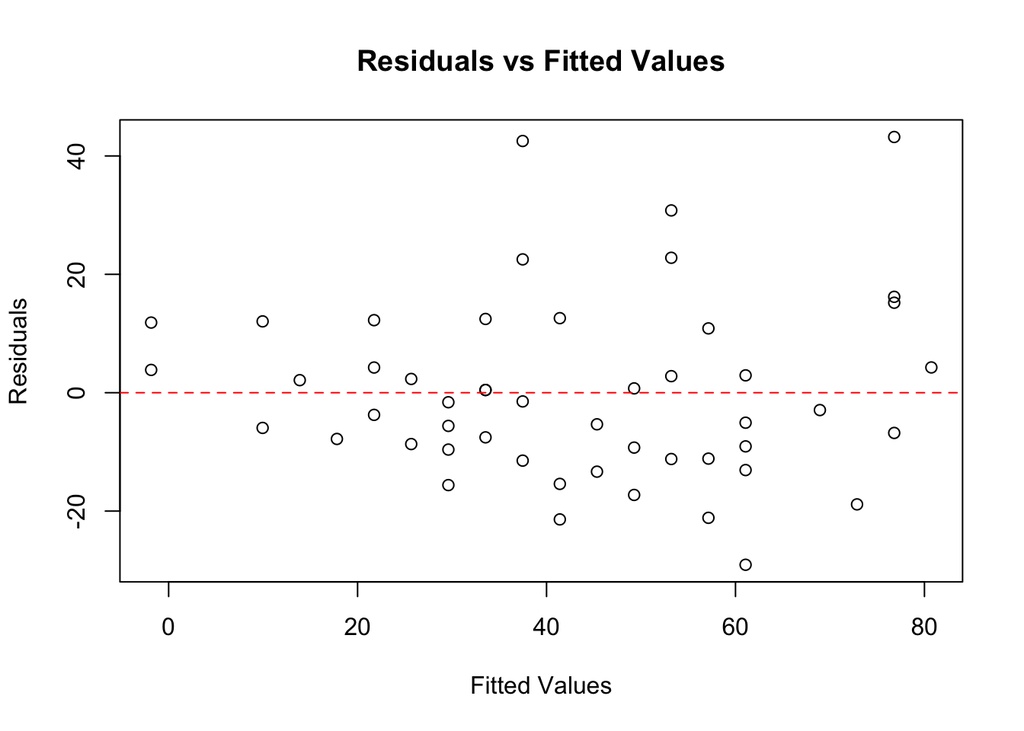

```r
plot(y_hat, fit$residuals, xlab = "Fitted Values", ylab = "Residuals",
     main = "Residuals vs Fitted Values")
abline(h = 0, col = "red", lty = 2)
```

Ideally, residuals should be randomly scattered around 0 with constant variance. Judgment by visual inspection, however, is subjective. Here, we observe that the spread of residuals seems to increase slightly as fitted values increase (potential violation of homoscedasticity).